# Final Project - Machine Learning 6620

December 12, 2024

Veronica Huerta Yumha

The present document its organized by use case and contains the most relevant part of the code implemented to get to the conclusions and results of the use cases described.

### Index

1. Predicting cell malignancy based on nuclear characteristics
2. Assessing heart disease risk based on a patient’s health conditions
3. Forecasting patient no-shows for medical appointments

## 1. Predicting cell malignancy based on nuclear characteristics

### Predicting Cell Malignancy Code

```python
# Importing necessary libraries
import pandas as pd
import numpy as np
import matplotlib.pyplot as plt
import seaborn as sns
from sklearn.model_selection import train_test_split, GridSearchCV
from sklearn.preprocessing import StandardScaler, LabelEncoder
from sklearn.linear_model import Lasso, Ridge, LassoCV
from sklearn.metrics import confusion_matrix, classification_report, roc_curve, roc_auc_score, precision_recall_curve, accuracy_score
from imblearn.over_sampling import SMOTE
```

```python
pip install ucimlrepo
```

```python
# Pulling the database. Code was obtained from https://archive.ics.uci.edu/dataset/17/breast+cancer+wisconsin+diagnostic
from ucimlrepo import fetch_ucirepo

# fetch dataset
breast_cancer_diagnostic = fetch_ucirepo(id=17)

# data (as pandas dataframes)
X = breast_cancer_diagnostic.data.features
y = breast_cancer_diagnostic.data.targets

# variable information
print(X.info())
```

```
<class 'pandas.core.frame.DataFrame'>
RangeIndex: 569 entries, 0 to 568
Data columns (total 30 columns):
 #   Column              Non-Null Count  Dtype
---  ------              --------------  -----
 0   radius1             569 non-null    float64
 1   texture1            569 non-null    float64
 2   perimeter1          569 non-null    float64
 3   area1               569 non-null    float64
 4   smoothness1         569 non-null    float64
 5   compactness1        569 non-null    float64
 6   concavity1          569 non-null    float64
 7   concave_points1     569 non-null    float64
 8   symmetry1           569 non-null    float64
 9   fractal_dimension1  569 non-null    float64
```

[output cut: 23 more lines]

#### Analysis of Variables

```python
# For simplicity on the analysis we will only use the 10 first columns
X = X.iloc[:, :10]
```

```python
X.describe()
```

|  | radius1 | texture1 | perimeter1 | area1 | smoothness1 | compactness1 | concavity1 | concave_points1 | symmetry1 | fractal_dimension1 |
| --- | --- | --- | --- | --- | --- | --- | --- | --- | --- | --- |
| count | 569.000000 | 569.000000 | 569.000000 | 569.000000 | 569.000000 | 569.000000 | 569.000000 | 569.000000 | 569.000000 | 569.000000 |
| mean | 14.127292 | 19.289649 | 91.969033 | 654.889104 | 0.096360 | 0.104341 | 0.088799 | 0.048919 | 0.181162 | 0.062798 |
| std | 3.524049 | 4.301036 | 24.298981 | 351.914129 | 0.014064 | 0.052813 | 0.079720 | 0.038803 | 0.027414 | 0.007060 |
| min | 6.981000 | 9.710000 | 43.790000 | 143.500000 | 0.052630 | 0.019380 | 0.000000 | 0.000000 | 0.106000 | 0.049960 |
| 25% | 11.700000 | 16.170000 | 75.170000 | 420.300000 | 0.086370 | 0.064920 | 0.029560 | 0.020310 | 0.161900 | 0.057700 |
| 50% | 13.370000 | 18.840000 | 86.240000 | 551.100000 | 0.095870 | 0.092630 | 0.061540 | 0.033500 | 0.179200 | 0.061540 |
| 75% | 15.780000 | 21.800000 | 104.100000 | 782.700000 | 0.105300 | 0.130400 | 0.130700 | 0.074000 | 0.195700 | 0.066120 |
| max | 28.110000 | 39.280000 | 188.500000 | 2501.000000 | 0.163400 | 0.345400 | 0.426800 | 0.201200 | 0.304000 | 0.097440 |

```python
y.info()
```

```
<class 'pandas.core.frame.DataFrame'>
RangeIndex: 569 entries, 0 to 568
Data columns (total 1 columns):
 #   Column     Non-Null Count  Dtype
---  ------     --------------  -----
 0   Diagnosis  569 non-null    object
dtypes: object(1)
memory usage: 4.6+ KB
```

```python
# Show count of each variable in y
print(y['Diagnosis'].value_counts())
```

```
Diagnosis
B    357
M    212
Name: count, dtype: int64
```

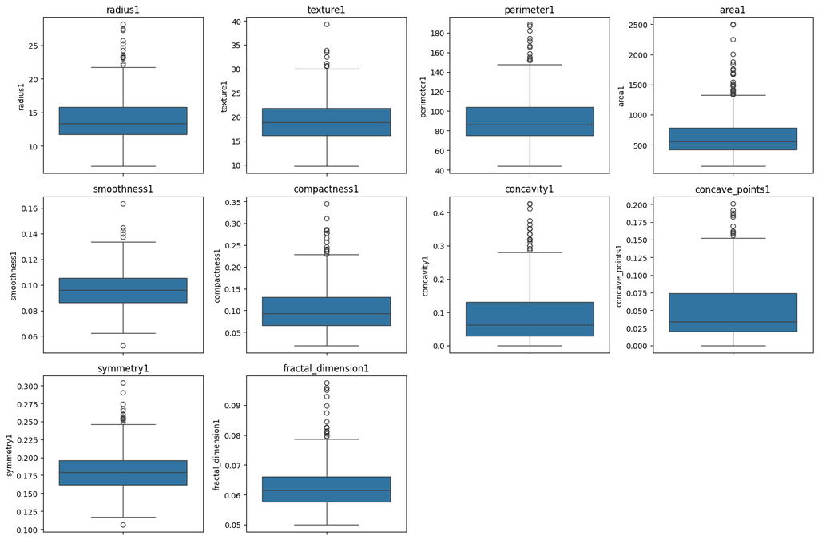

```python
# Checking variables for outliers
# Creating box plots for each variable to visually identify outliers
plt.figure(figsize=(15, 10))
for i, col in enumerate(X.columns):
    plt.subplot(3, 4, i + 1)
    sns.boxplot(y=X[col])
    plt.title(col)
plt.tight_layout()
plt.show()
```

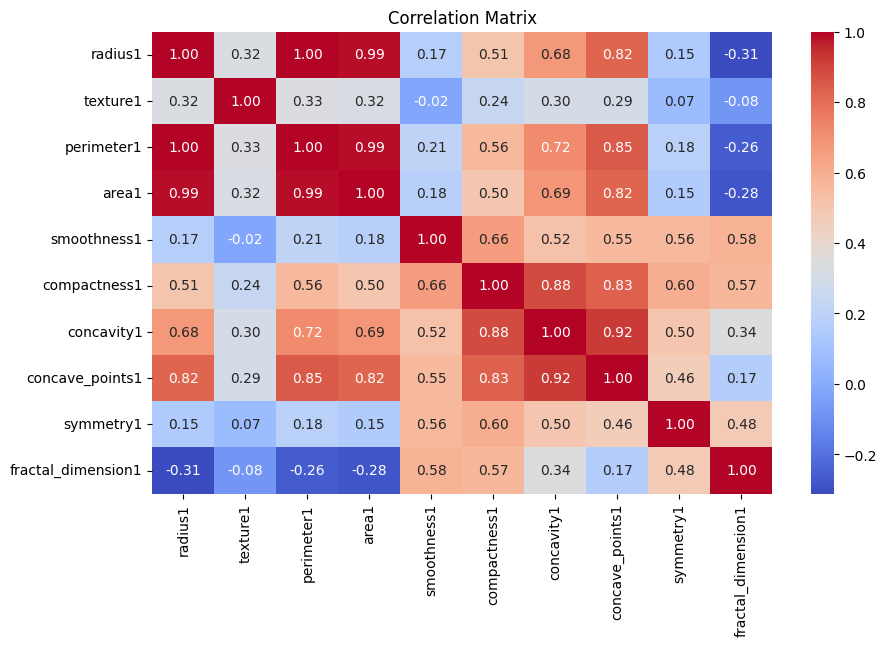

```python
# Checking there is no independence on the variables of X
correlation_matrix = X.corr()

# Visualize the correlation matrix using a heatmap
plt.figure(figsize=(10, 6))
sns.heatmap(correlation_matrix, annot=True, cmap='coolwarm', fmt=".2f")
plt.title('Correlation Matrix')
plt.show()
```

To avoid dependency of variables will get rid of the area and perimeter.

```python
# Removing perimeter1 and area1 from X
X = X.drop(['perimeter1', 'area1'], axis=1)
X.info()
```

```
<class 'pandas.core.frame.DataFrame'>
RangeIndex: 569 entries, 0 to 568
Data columns (total 8 columns):
 #   Column              Non-Null Count  Dtype
---  ------              --------------  -----
 0   radius1             569 non-null    float64
 1   texture1            569 non-null    float64
 2   smoothness1         569 non-null    float64
 3   compactness1        569 non-null    float64
 4   concavity1          569 non-null    float64
 5   concave_points1     569 non-null    float64
 6   symmetry1           569 non-null    float64
 7   fractal_dimension1  569 non-null    float64
dtypes: float64(8)
memory usage: 35.7 KB
```

Suitability for Analysis Method

#### Implementing a Penalized Regression Model, we will use Lasso then Ridge and compare

```python
# Split the data into training and testing sets
X_train, X_test, y_train, y_test = train_test_split(X, y, test_size=0.2, random_state=42)
```

```python
# Standardize the feature variables (mean=0, std=1)
scaler = StandardScaler()
X_train_scaled = scaler.fit_transform(X_train)
X_test_scaled = scaler.transform(X_test)
```

```python
# Create a LabelEncoder object
label_encoder = LabelEncoder()

# Fit the encoder to your 'Diagnosis' column in y_train and transform it
y_train = label_encoder.fit_transform(y_train['Diagnosis'])

# Transform y_test as well using the same encoder
y_test = label_encoder.transform(y_test['Diagnosis'])
```

Lasso Regression

```python
# Create a Lasso regression model (L1 regularization)
lasso_model = Lasso(alpha=0.01)  # Alpha controls the regularization strength
lasso_model.fit(X_train_scaled, y_train)

# Predict on the test set
y_pred_lasso = lasso_model.predict(X_test_scaled)
y_pred_lasso = [1 if i >= 0.5 else 0 for i in y_pred_lasso]  # Convert to binary

# Evaluate Lasso model
lasso_accuracy = accuracy_score(y_test, y_pred_lasso)
print(f"Lasso Regression Accuracy: {lasso_accuracy:.2f}")
```

```
Lasso Regression Accuracy: 0.95
```

Ridge Regression

```python
# Create a Ridge regression model (L2 regularization)
ridge_model = Ridge(alpha=10)  # Alpha controls the regularization strength
ridge_model.fit(X_train_scaled, y_train)

# Predict on the test set
y_pred_ridge = ridge_model.predict(X_test_scaled)
y_pred_ridge = [1 if i >= 0.5 else 0 for i in y_pred_ridge]  # Convert to binary

# Evaluate Ridge model
ridge_accuracy = accuracy_score(y_test, y_pred_ridge)
print(f"Ridge Regression Accuracy: {ridge_accuracy:.2f}")
```

```
Ridge Regression Accuracy: 0.95
```

```python
# Confusion matrix for Lasso
print("Lasso Confusion Matrix:")
print(confusion_matrix(y_test, y_pred_lasso))

# Confusion matrix for Ridge
print("Ridge Confusion Matrix:")
print(confusion_matrix(y_test, y_pred_ridge))
```

```
Lasso Confusion Matrix:
[[71  0]
 [ 6 37]]
Ridge Confusion Matrix:
[[70  1]
 [ 5 38]]
```

Fine-Tune the Alpha Parameter and afterwards interning into the code

```python
# Fine-tuning alpha for Lasso
lasso_cv = GridSearchCV(Lasso(), param_grid={'alpha': [0.01, 0.1, 1, 10]}, cv=5)
lasso_cv.fit(X_train_scaled, y_train)
print(f"Best alpha for Lasso: {lasso_cv.best_params_['alpha']}")

# Fine-tuning alpha for Ridge
ridge_cv = GridSearchCV(Ridge(), param_grid={'alpha': [0.01, 0.1, 1, 10]}, cv=5)
ridge_cv.fit(X_train_scaled, y_train)
print(f"Best alpha for Ridge: {ridge_cv.best_params_['alpha']}")
```

```
Best alpha for Lasso: 0.01
Best alpha for Ridge: 10
```

Both the Lasso and Ridge regressions have high accuracy (0.95) after ajusting the alpha parameter. We will choose the Lasso to test its performance and robusteness further.

#### Accuracy, Performance and Robustness Checks for Lasso Model

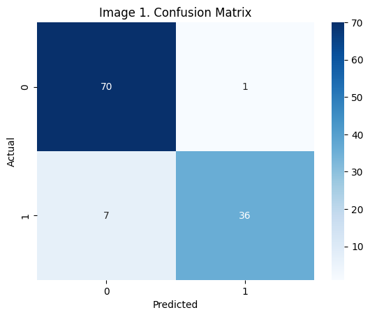

```
 Table 1. Classification Report
               precision    recall  f1-score   support

           0       0.91      0.99      0.95        71
           1       0.97      0.84      0.90        43

    accuracy                           0.93       114
   macro avg       0.94      0.91      0.92       114
weighted avg       0.93      0.93      0.93       114
```

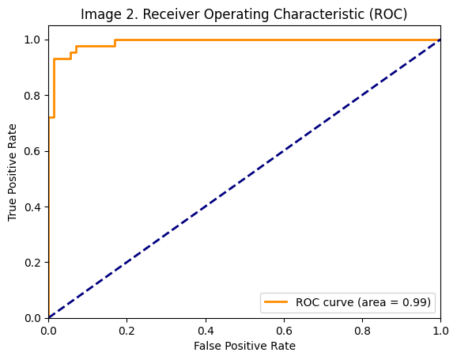

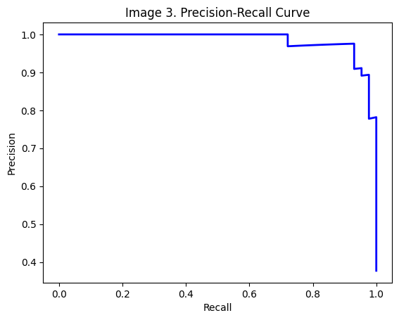

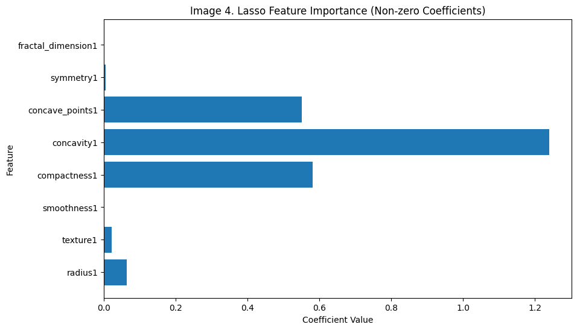

```python
# Fit the Lasso Regression model
lasso = LassoCV(cv=5, random_state=0).fit(X_train, y_train)

# Predictions on test data
y_pred = lasso.predict(X_test)

# Convert predictions to binary for classification
y_pred_class = np.where(y_pred > 0.5, 1, 0)

# 1. Confusion Matrix
cm = confusion_matrix(y_test, y_pred_class)
sns.heatmap(cm, annot=True, fmt="d", cmap="Blues")
plt.title('Image 1. Confusion Matrix')
plt.xlabel('Predicted')
plt.ylabel('Actual')
plt.show()

# 2. Classification Report for Precision, Recall, and F1-Score
print("\n Table 1. Classification Report\n", classification_report(y_test, y_pred_class))

# 3. ROC Curve
fpr, tpr, _ = roc_curve(y_test, y_pred)
roc_auc = roc_auc_score(y_test, y_pred)

plt.figure()
plt.plot(fpr, tpr, color='darkorange', lw=2, label='ROC curve (area = %0.2f)' % roc_auc)
plt.plot([0, 1], [0, 1], color='navy', lw=2, linestyle='--')
plt.xlim([0.0, 1.0])
plt.ylim([0.0, 1.05])
plt.xlabel('False Positive Rate')
plt.ylabel('True Positive Rate')
plt.title('Image 2. Receiver Operating Characteristic (ROC)')
plt.legend(loc="lower right")
plt.show()

# 4. Precision-Recall Curve
precision, recall, _ = precision_recall_curve(y_test, y_pred)

plt.figure()
plt.plot(recall, precision, color='b', lw=2)
plt.xlabel('Recall')
plt.ylabel('Precision')
plt.title('Image 3. Precision-Recall Curve')
print("\n")
plt.show()

# 5. Feature Importance (Lasso Coefficients)
plt.figure(figsize=(10, 6))
plt.barh(X.columns, lasso.coef_)
plt.title('Image 4. Lasso Feature Importance (Non-zero Coefficients)')
plt.xlabel('Coefficient Value')
plt.ylabel('Feature')
print("\n")
plt.show()
```

```python
# Lasso regression with balanced data and excluding fractal dimension1 and smoothness1 variables

# Remove 'fractal_dimension1' and 'smoothness1'
#X = X.drop(['fractal_dimension1', 'smoothness1'], axis=1)

# Split data
X_train, X_test, y_train, y_test = train_test_split(X, y, test_size=0.2, random_state=42)

# Scale data
scaler = StandardScaler()
X_train_scaled = scaler.fit_transform(X_train)
X_test_scaled = scaler.transform(X_test)

# Encode target variable
label_encoder = LabelEncoder()
y_train_encoded = label_encoder.fit_transform(y_train['Diagnosis'])
y_test_encoded = label_encoder.transform(y_test['Diagnosis'])

# Balance the data using SMOTE
smote = SMOTE(random_state=42)
X_train_resampled, y_train_resampled = smote.fit_resample(X_train_scaled, y_train_encoded)


# Lasso Regression with Cross-Validation
lasso_cv = LassoCV(cv=5, random_state=0)
lasso_cv.fit(X_train_resampled, y_train_resampled)

# Predict on the test set
y_pred = lasso_cv.predict(X_test_scaled)
y_pred_class = np.where(y_pred > 0.5, 1, 0)

# Evaluate the model
accuracy = accuracy_score(y_test_encoded, y_pred_class)
print(f"Accuracy: {accuracy}")

# Classification Report for Precision, Recall, and F1-Score
print("\nClassification Report:")
report = classification_report(y_test_encoded, y_pred_class, output_dict=True)
report_df = pd.DataFrame(report).transpose()
report_df
```

```
Accuracy: 0.9473684210526315

Classification Report:
```

|  | precision | recall | f1-score | support |
| --- | --- | --- | --- | --- |
| 0 | 0.945205 | 0.971831 | 0.958333 | 71.000000 |
| 1 | 0.951220 | 0.906977 | 0.928571 | 43.000000 |
| accuracy | 0.947368 | 0.947368 | 0.947368 | 0.947368 |
| macro avg | 0.948212 | 0.939404 | 0.943452 | 114.000000 |
| weighted avg | 0.947474 | 0.947368 | 0.947107 | 114.000000 |

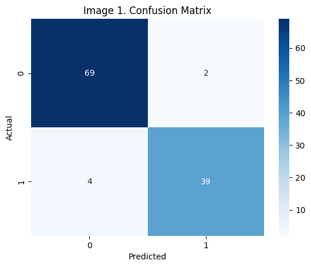

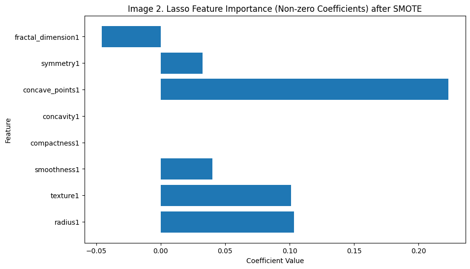

```python
# 1. Confusion Matrix
cm = confusion_matrix(y_test_encoded, y_pred_class)
sns.heatmap(cm, annot=True, fmt="d", cmap="Blues")
plt.title('Image 1. Confusion Matrix')
plt.xlabel('Predicted')
plt.ylabel('Actual')
plt.show()
print("\n")

# 2. Feature Importance (Lasso Coefficients) after SMOTE
plt.figure(figsize=(10, 6))
plt.barh(X.columns, lasso_cv.coef_)
plt.title('Image 2. Lasso Feature Importance (Non-zero Coefficients) after SMOTE')
plt.xlabel('Coefficient Value')
plt.ylabel('Feature')
plt.show()
```

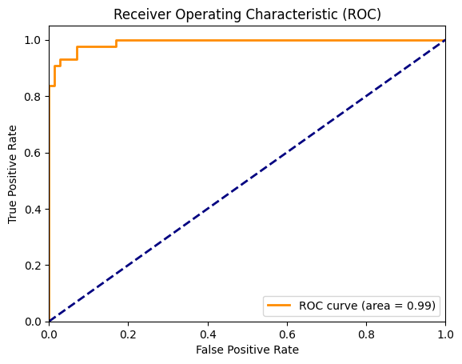

```python
# 3. ROC Curve
fpr, tpr, _ = roc_curve(y_test_encoded, y_pred) # Use y_pred, not y_pred_class for ROC curve
roc_auc = roc_auc_score(y_test_encoded, y_pred)

plt.figure()
plt.plot(fpr, tpr, color='darkorange', lw=2, label='ROC curve (area = %0.2f)' % roc_auc)
plt.plot([0, 1], [0, 1], color='navy', lw=2, linestyle='--')
plt.xlim([0.0, 1.0])
plt.ylim([0.0, 1.05])
plt.xlabel('False Positive Rate')
plt.ylabel('True Positive Rate')
plt.title('Receiver Operating Characteristic (ROC)')
plt.legend(loc="lower right")
plt.show()
```

## 2. Assessing heart disease risk based on a patient’s health conditions

### Assessing Heart Disease Risk Code

1. Which machine learning methods did you implement? K-Means clustering, with and without implementing Principal Component Analysis (PCA) before.
2. Discuss the key contribution of each method to your analysis
- K-Means Clustering: This method provided a baseline for grouping patients based on their health conditions. The initial K-Means clustering, without PCA, served as a baseline for comparison.
- Principal Component Analysis (PCA): PCA was used for dimensionality reduction and it significantly improved the clustering performance, as indicated by the higher Silhouette Score.
3. Did all methods support your conclusions or did some provide conflicting results? The methods supported the conclusion that applying PCA before K-Means improved the quality of the clusters.

```python
pip install ucimlrepo
```

```
Downloading ucimlrepo-0.0.7-py3-none-any.whl (8.0 kB)
```

```python
from ucimlrepo import fetch_ucirepo

# fetch dataset
heart_disease = fetch_ucirepo(id=45)

# data (as pandas dataframes)
X = heart_disease.data.features
y = heart_disease.data.targets

# metadata
#print(heart_disease.metadata)

# variable information
print(heart_disease.variables)
```

```
        name     role         type demographic  \
0        age  Feature      Integer         Age
1        sex  Feature  Categorical         Sex
2         cp  Feature  Categorical        None
3   trestbps  Feature      Integer        None
4       chol  Feature      Integer        None
5        fbs  Feature  Categorical        None
6    restecg  Feature  Categorical        None
7    thalach  Feature      Integer        None
8      exang  Feature  Categorical        None
9    oldpeak  Feature      Integer        None
10     slope  Feature  Categorical        None
11        ca  Feature      Integer        None
12      thal  Feature  Categorical        None
13       num   Target      Integer        None
```

[output cut: 16 more lines]

#### K-Means Clustering

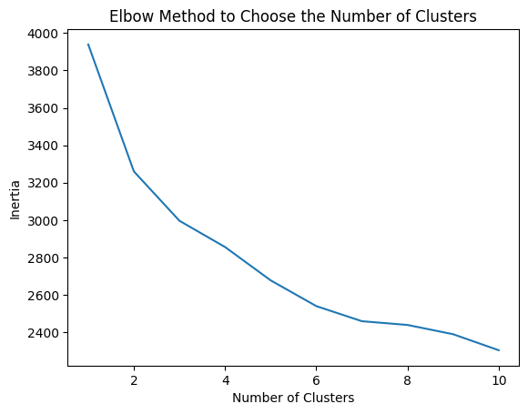

```python
# Import necessary libraries
import pandas as pd
import numpy as np
import matplotlib.pyplot as plt
from sklearn.model_selection import train_test_split
from sklearn.preprocessing import StandardScaler
from sklearn.cluster import KMeans
from sklearn.metrics import silhouette_score
# Import SimpleImputer for handling missing values
from sklearn.impute import SimpleImputer # Importing SimpleImputer

# Preprocess the data
# Impute missing values in the entire DataFrame before scaling and splitting
imputer = SimpleImputer(strategy='mean') # Replace 'mean' with other strategies if needed
X = pd.DataFrame(imputer.fit_transform(X), columns=X.columns) # Impute on X

# Select relevant features (e.g., exclude non-numeric columns)
# Assuming 'target' or 'num' is the column to predict, exclude it
features = X.copy() # Create a copy of X to avoid modifying the original DataFrame

# Feature scaling
# Apply the same preprocessing to 'features' as you did to 'df'
features = features.dropna() # Drop rows with missing values in 'features'
scaler = StandardScaler()
df_scaled = scaler.fit_transform(features)  # Standardize the data to have 0 mean and unit variance

# Determine the optimal number of clusters using the Elbow Method
inertia = []  # To store inertia values for different cluster sizes
for i in range(1, 11):  # Try between 1 and 10 clusters
    kmeans = KMeans(n_clusters=i, random_state=42)
    kmeans.fit(df_scaled)
    inertia.append(kmeans.inertia_)

# Plot the Elbow Method
plt.plot(range(1, 11), inertia)
plt.title('Elbow Method to Choose the Number of Clusters')
plt.xlabel('Number of Clusters')
plt.ylabel('Inertia')
plt.show()
```

```python
# Evaluating silhouette score by number of clusters

# Evaluate the clustering performance for different k values
for n_clusters in range(2, 11):  # Test for 2 to 10 clusters
    kmeans = KMeans(n_clusters=n_clusters, random_state=42)
    cluster_labels = kmeans.fit_predict(df_scaled)
    sil_score = silhouette_score(df_scaled, cluster_labels)
    print(f"For n_clusters = {n_clusters}, the silhouette score is {sil_score}")
```

```
For n_clusters = 2, the silhouette score is 0.17520814103477603
For n_clusters = 3, the silhouette score is 0.12857066474100456
For n_clusters = 4, the silhouette score is 0.11652896722868053
For n_clusters = 5, the silhouette score is 0.12261772465773822
For n_clusters = 6, the silhouette score is 0.12021040904918075
For n_clusters = 7, the silhouette score is 0.10783800832062855
For n_clusters = 8, the silhouette score is 0.1034117603957617
For n_clusters = 9, the silhouette score is 0.09222381550167105
For n_clusters = 10, the silhouette score is 0.09362432622787313
```

The higher silhoutte score is 0.17520814103477603 for n_clusters = 2

```
               age       sex        cp    trestbps        chol       fbs  \
Cluster
0        58.173913  0.817391  3.773913  134.904348  254.226087  0.200000
1        52.154255  0.595745  2.781915  129.723404  242.085106  0.117021

          restecg     thalach     exang   oldpeak     slope        ca  \
Cluster
0        1.208696  133.147826  0.678261  1.866957  1.965217  1.249324
1        0.856383  159.675532  0.111702  0.533511  1.377660  0.319238

             thal
Cluster
0        6.154211
1        3.865608
Silhouette Score: 0.17520814103477603
```

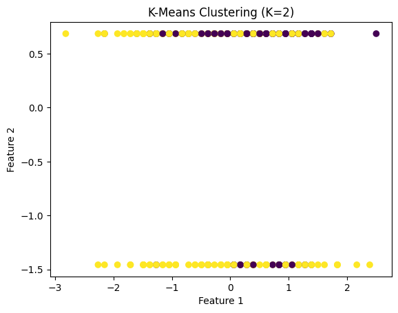

```
Cluster sizes:
Cluster
1    188
0    115
Name: count, dtype: int64
```

```python
# Apply K-Means clustering with the chosen number of clusters
optimal_clusters = 2  # Based on Elbow Method (adjust this value based on the plot)
kmeans = KMeans(n_clusters=optimal_clusters, random_state=42)
clusters = kmeans.fit_predict(df_scaled)

# Add the cluster labels to the original DataFrame
# Make sure 'df' and 'clusters' have the same number of rows
df = features.copy()  # OR: df = df.reset_index(drop=True) # If you want to keep the original 'df' but reset its index
df['Cluster'] = clusters

# Analyze the clusters by calculating the mean of each feature for each cluster
print(df.groupby('Cluster').mean())  # Mean values for each feature in each cluster

# Evaluate the clustering performance using the Silhouette Score
sil_score = silhouette_score(df_scaled, clusters)
print(f"Silhouette Score: {sil_score}")

# Visualize the clustering (optional if features are high-dimensional)
# Using two features for visualization (e.g., the first two columns)
plt.scatter(df_scaled[:, 0], df_scaled[:, 1], c=clusters, cmap='viridis')
plt.title(f'K-Means Clustering (K={optimal_clusters})')
plt.xlabel('Feature 1')
plt.ylabel('Feature 2')
plt.show()

# Cluster distribution (size of each cluster)
cluster_sizes = df['Cluster'].value_counts()
print(f"Cluster sizes:\n{cluster_sizes}")
```

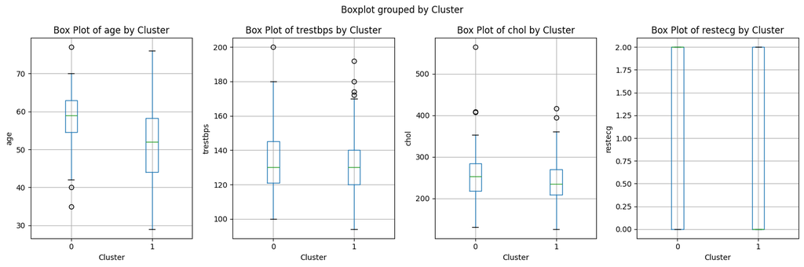

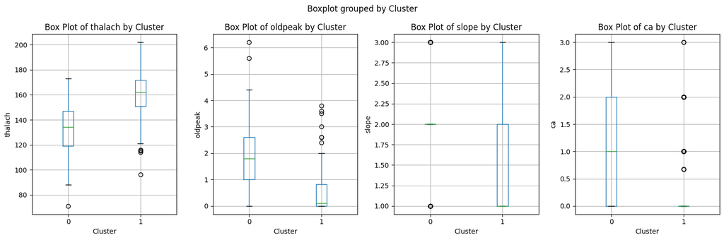

```python
# box plot of the variables of numerical variables of the different clusters

features_to_plot = ['age', 'trestbps', 'chol', 'restecg', 'thalach', 'oldpeak', 'slope', 'ca']
num_plots_per_line = 4  # Number of box plots to display per line

num_lines = (len(features_to_plot) + num_plots_per_line - 1) // num_plots_per_line

for i in range(num_lines):
    fig, axes = plt.subplots(1, min(num_plots_per_line, len(features_to_plot) - i * num_plots_per_line), figsize=(15, 5))

    for j in range(min(num_plots_per_line, len(features_to_plot) - i * num_plots_per_line)):
        feature_index = i * num_plots_per_line + j
        feature = features_to_plot[feature_index]

        if isinstance(axes, np.ndarray): # Handle multiple subplots
          ax = axes[j]
          df.boxplot(column=feature, by='Cluster', ax=ax)
          ax.set_title(f'Box Plot of {feature} by Cluster')
          ax.set_ylabel(feature)
          ax.set_xlabel('Cluster')
        else: # Handle single subplot case
          df.boxplot(column=feature, by='Cluster', ax=axes)
          axes.set_title(f'Box Plot of {feature} by Cluster')
          axes.set_ylabel(feature)
          axes.set_xlabel('Cluster')

    plt.tight_layout()
    plt.show()
```

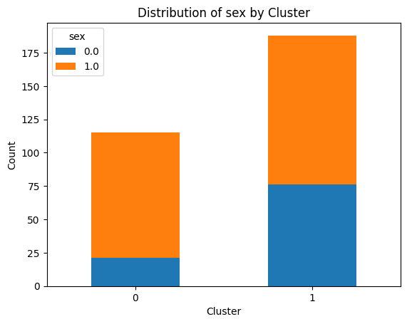

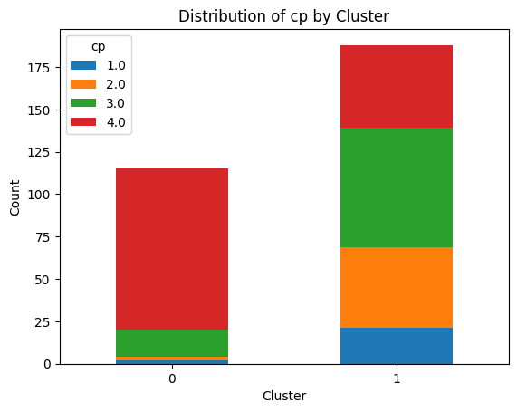

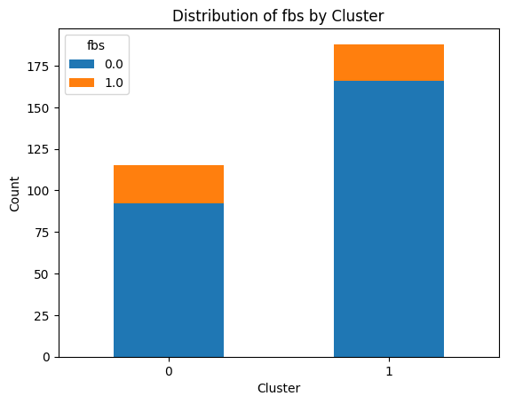

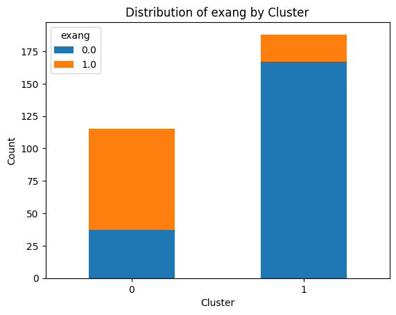

```python
# Plot categorical variables by cluster into separeted piled bars graphs

features_to_plot = ['sex', 'cp', 'fbs', 'exang']

for feature in features_to_plot:
    # Calculate value counts for each cluster
    cluster_counts = df.groupby('Cluster')[feature].value_counts().unstack(fill_value=0)

    # Create the stacked bar plot
    cluster_counts.plot(kind='bar', stacked=True)
    plt.title(f'Distribution of {feature} by Cluster')
    plt.xlabel('Cluster')
    plt.ylabel('Count')
    plt.xticks(rotation=0)  # Rotate x-axis labels for better readability
    plt.legend(title=feature)
    plt.show()
```

#### Implementing PCA

```python
# Importing necessary libraries
from sklearn.decomposition import PCA
import seaborn as sns

# data (as pandas dataframes)
X = heart_disease.data.features
y = heart_disease.data.targets

# Accessing the features as a DataFrame
df = X # Assign X to df to avoid confusion

# Impute missing values in the entire DataFrame before scaling and splitting
imputer = SimpleImputer(strategy='mean') # Replace 'mean' with other strategies if needed
X = pd.DataFrame(imputer.fit_transform(X), columns=X.columns) # Impute on X

print(X)
print(y)
```

```
      age  sex   cp  trestbps   chol  fbs  restecg  thalach  exang  oldpeak  \
0    63.0  1.0  1.0     145.0  233.0  1.0      2.0    150.0    0.0      2.3
1    67.0  1.0  4.0     160.0  286.0  0.0      2.0    108.0    1.0      1.5
2    67.0  1.0  4.0     120.0  229.0  0.0      2.0    129.0    1.0      2.6
3    37.0  1.0  3.0     130.0  250.0  0.0      0.0    187.0    0.0      3.5
4    41.0  0.0  2.0     130.0  204.0  0.0      2.0    172.0    0.0      1.4
..    ...  ...  ...       ...    ...  ...      ...      ...    ...      ...
298  45.0  1.0  1.0     110.0  264.0  0.0      0.0    132.0    0.0      1.2
299  68.0  1.0  4.0     144.0  193.0  1.0      0.0    141.0    0.0      3.4
300  57.0  1.0  4.0     130.0  131.0  0.0      0.0    115.0    1.0      1.2
301  57.0  0.0  2.0     130.0  236.0  0.0      2.0    174.0    0.0      0.0
302  38.0  1.0  3.0     138.0  175.0  0.0      0.0    173.0    0.0      0.0

     slope        ca  thal
0      3.0  0.000000   6.0
```

[output cut: 26 more lines]

```
Training set size: 242, Test set size: 61
Training set target distribution:
num
0      0.557851
1      0.177686
3      0.115702
2      0.111570
4      0.037190
Name: proportion, dtype: float64
Test set target distribution:
num
0      0.475410
1      0.196721
2      0.147541
3      0.114754
4      0.065574
Name: proportion, dtype: float64
```

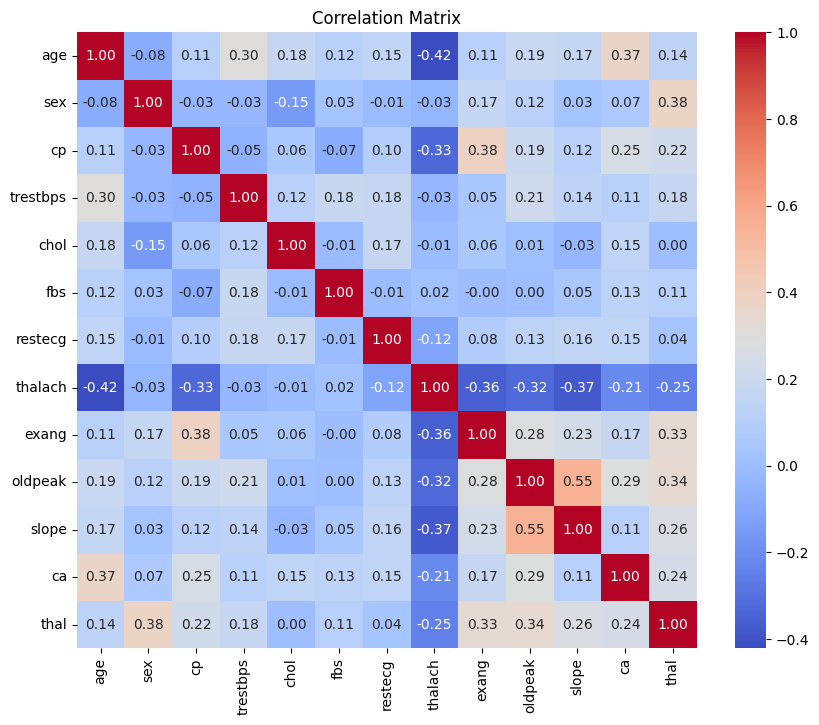

```
Variances (Descending): [2.68084919e+03 5.23265775e+02 3.09751120e+02 8.16974187e+01
 3.73754153e+00 1.34809521e+00 9.89967871e-01 9.21841191e-01
 8.67150989e-01 3.79734662e-01 2.20706839e-01 2.18368194e-01
 1.26876926e-01]
Coefficient of Variation (Descending): [10.86714433  3.49759612  2.35212745  1.50071645  1.2967392   1.28994102
  0.99986755  0.85430464  0.78947368  0.67549669  0.32119205  0.29186821
  0.23723629]
Explained Variance Ratio: [0.23559604 0.1198257  0.10422876 0.08666767 0.07640347 0.06464672
 0.06087841 0.05929341 0.05345665 0.04369831 0.03626514 0.03014366
 0.02889607]
```

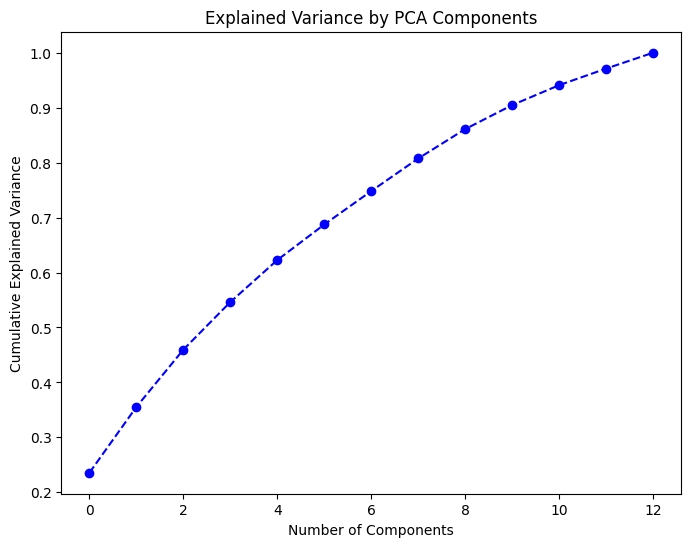

```
PCA on Top Variables - Explained Variance Ratio: [0.34091767 0.22186445 0.17657866 0.16398423 0.096655  ]
```

```python
# Step 4: Standardize the features
scaler = StandardScaler()
X_scaled = scaler.fit_transform(X) # Use the imputed X

# Step 5: Split Data into Training and Test Sets
train_size = 0.8
random_seed = 42
X_train, X_test, y_train, y_test = train_test_split(
    X_scaled, y, test_size=(1 - train_size), random_state=random_seed
)

# Step 6: Verify Data Split
print(f"Training set size: {X_train.shape[0]}, Test set size: {X_test.shape[0]}")
print("Training set target distribution:")
print(y_train.value_counts(normalize=True))
print("Test set target distribution:")
print(y_test.value_counts(normalize=True))

# Step 7: Calculate and Visualize Correlation
correlation_matrix = pd.DataFrame(X_train, columns=X.columns).corr()
plt.figure(figsize=(10, 8))
sns.heatmap(correlation_matrix, annot=True, cmap="coolwarm", fmt=".2f", cbar=True)
plt.title("Correlation Matrix")
plt.show()

# Step 8: Calculate and Sort Variances
variances = X.var(axis=0)
sorted_variances = np.sort(variances)[::-1]
print("Variances (Descending):", sorted_variances)

# Step 9: Calculate and Sort Coefficient of Variation
mean = X.mean(axis=0)
cv = variances / mean
sorted_cv = np.sort(cv)[::-1]
print("Coefficient of Variation (Descending):", sorted_cv)

# Step 10: Perform Principal Component Analysis (PCA)
pca = PCA()
pca_result = pca.fit_transform(X_train)

# Explained variance ratio
explained_variance_ratio = pca.explained_variance_ratio_
print("Explained Variance Ratio:", explained_variance_ratio)

# Plot Explained Variance Ratio
plt.figure(figsize=(8, 6))
plt.plot(
    np.cumsum(explained_variance_ratio), marker="o", linestyle="--", color="b"
)
plt.xlabel("Number of Components")
plt.ylabel("Cumulative Explained Variance")
plt.title("Explained Variance by PCA Components")
plt.show()

# Step 11: Repeat PCA with Different Variables (Optional)
# Selecting top N variables by variance or other metrics for PCA
top_vars = np.argsort(variances)[-5:]  # Top 5 variables by variance
X_selected = X.iloc[:, top_vars]
X_selected_scaled = scaler.fit_transform(X_selected)

pca_selected = PCA()
pca_selected_result = pca_selected.fit_transform(X_selected_scaled)

print("PCA on Top Variables - Explained Variance Ratio:", pca_selected.explained_variance_ratio_)
```

```
Top variables:  exang      12
oldpeak     0
slope       3
ca          7
thal        4
dtype: int64
```

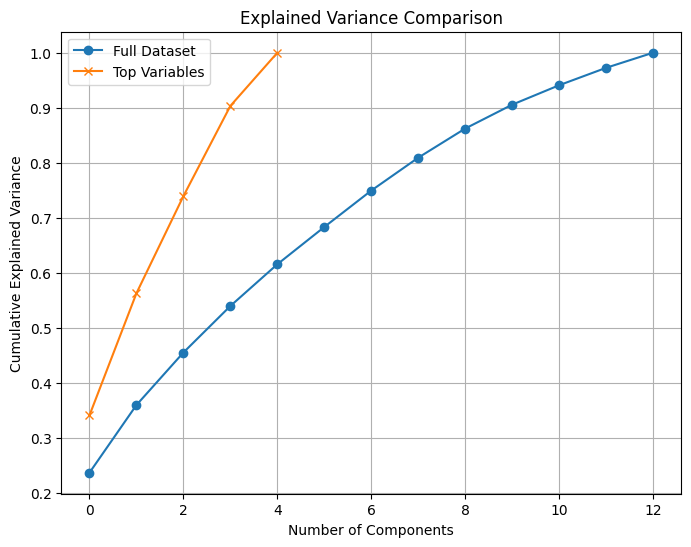

```
Reconstruction Error - Full Dataset: 1.2573413214679064e-30
Reconstruction Error - Top Variables: 1.9704782575880898e-31
```

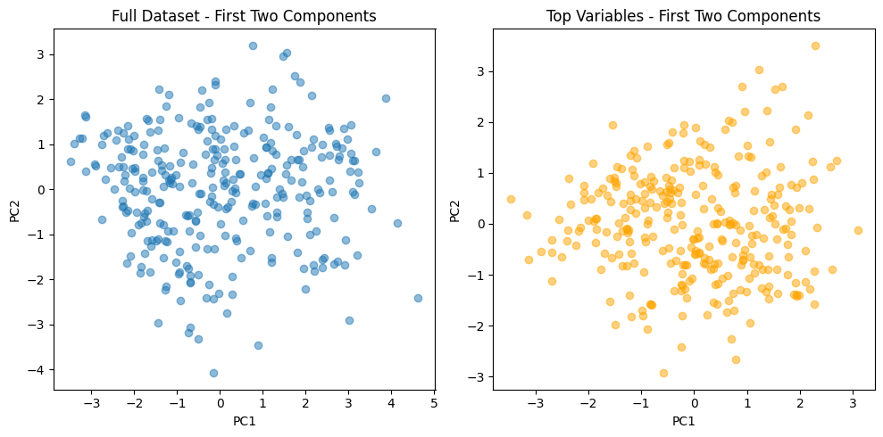

```python
# Step 1: Load the dataset
X_full = X.copy()  # Full dataset

# Step 2: Calculate variances to find impactful variables
variances = X.var(axis=0)
top_indices = np.argsort(variances)[-5:]  # Top 5 variables by variance
X_top_vars = X.iloc[:, top_indices]
print("Top variables: ", top_indices,"\n")

# Step 3: Standardize the datasets
scaler = StandardScaler()
X_full_scaled = scaler.fit_transform(X_full)
X_top_scaled = scaler.fit_transform(X_top_vars)

# Step 4: Apply PCA on full dataset
pca_full = PCA()
pca_full_result = pca_full.fit_transform(X_full_scaled)
explained_variance_full = np.cumsum(pca_full.explained_variance_ratio_)

# Step 5: Apply PCA on most impactful variables
pca_top = PCA()
pca_top_result = pca_top.fit_transform(X_top_scaled)
explained_variance_top = np.cumsum(pca_top.explained_variance_ratio_)

# Step 6: Compare explained variance
plt.figure(figsize=(8, 6))
plt.plot(
    explained_variance_full, label="Full Dataset", marker="o"
)
plt.plot(
    explained_variance_top, label="Top Variables", marker="x"
)
plt.xlabel("Number of Components")
plt.ylabel("Cumulative Explained Variance")
plt.title("Explained Variance Comparison")
plt.legend()
plt.grid()
plt.show()

# Step 7: Calculate Reconstruction Error
def reconstruction_error(pca, X_scaled):
    X_reduced = pca.transform(X_scaled)
    X_reconstructed = pca.inverse_transform(X_reduced)
    return np.mean((X_scaled - X_reconstructed)**2)

error_full = reconstruction_error(pca_full, X_full_scaled)
error_top = reconstruction_error(pca_top, X_top_scaled)

print(f"Reconstruction Error - Full Dataset: {error_full}")
print(f"Reconstruction Error - Top Variables: {error_top}")

# Step 8: Visualize first two principal components for both cases
plt.figure(figsize=(10, 5))

plt.subplot(1, 2, 1)
plt.scatter(pca_full_result[:, 0], pca_full_result[:, 1], alpha=0.5)
plt.title("Full Dataset - First Two Components")
plt.xlabel("PC1")
plt.ylabel("PC2")

plt.subplot(1, 2, 2)
plt.scatter(pca_top_result[:, 0], pca_top_result[:, 1], alpha=0.5, color='orange')
plt.title("Top Variables - First Two Components")
plt.xlabel("PC1")
plt.ylabel("PC2")

plt.tight_layout()
plt.show()
```

#### Clustering with K-Means after Applying PCA

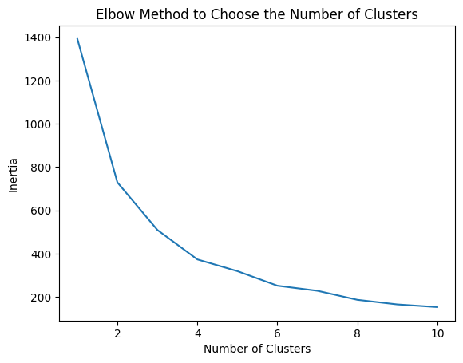

```python
# Preprocess the data
# Handle missing values (e.g., drop or impute missing values)
df = df.dropna()  # Or you could use imputation, e.g., df.fillna(df.mean())

# Feature scaling
scaler = StandardScaler()
df_scaled = scaler.fit_transform(df)  # Standardize the data to have 0 mean and unit variance

# Reduce to 2 components if needed
pca = PCA(n_components=2)
df_pca = pca.fit_transform(df_scaled)

# Step 6: Determine the optimal number of clusters using the Elbow Method
inertia = []  # To store inertia values for different cluster sizes
for i in range(1, 11):  # Try between 1 and 10 clusters
    kmeans = KMeans(n_clusters=i, random_state=42)
    kmeans.fit(df_pca)  # Use PCA components for clustering
    inertia.append(kmeans.inertia_)

# Plot the Elbow Method
plt.plot(range(1, 11), inertia)
plt.title('Elbow Method to Choose the Number of Clusters')
plt.xlabel('Number of Clusters')
plt.ylabel('Inertia')
plt.show()
```

```python
# Print silhouette score for each number of clusters

# Preprocess the data
imputer = SimpleImputer(strategy='mean')
X = pd.DataFrame(imputer.fit_transform(X), columns=X.columns)

scaler = StandardScaler()
X_scaled = scaler.fit_transform(X)

# Apply PCA
pca = PCA(n_components=2) # Reduce to 2 components for visualization
X_pca = pca.fit_transform(X_scaled)

# Calculate silhouette scores for different k values
for n_clusters in range(2, 11):
    kmeans = KMeans(n_clusters=n_clusters, random_state=42)
    cluster_labels = kmeans.fit_predict(X_pca)
    sil_score = silhouette_score(X_pca, cluster_labels)
    print(f"For n_clusters = {n_clusters}, the silhouette score is {sil_score}")
```

```
For n_clusters = 2, the silhouette score is 0.4238135902928524
For n_clusters = 3, the silhouette score is 0.33737164016293325
For n_clusters = 4, the silhouette score is 0.3875189362430926
For n_clusters = 5, the silhouette score is 0.3381814832684922
For n_clusters = 6, the silhouette score is 0.35333549747041015
For n_clusters = 7, the silhouette score is 0.36444856479876836
For n_clusters = 8, the silhouette score is 0.35078417328490014
For n_clusters = 9, the silhouette score is 0.34147958022320324
For n_clusters = 10, the silhouette score is 0.33987436776436597
```

n_clusters = 2 has the better score

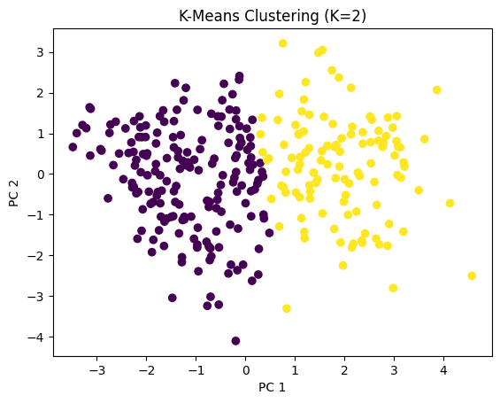

```
               age       sex        cp    trestbps        chol       fbs  \
Cluster
0        52.189189  0.600000  2.805405  129.443243  243.000000  0.118919
1        58.428571  0.803571  3.741071  135.410714  254.535714  0.187500

          restecg     thalach     exang   oldpeak     slope       ca      thal
Cluster
0        0.870270  160.124324  0.118919  0.529189  1.367568  0.32973  3.886486
1        1.205357  132.214286  0.669643  1.925000  1.991071  1.25000  6.125000
Silhouette Score: 0.42428994396164216
Cluster sizes:
Cluster
0    185
1    112
Name: count, dtype: int64
```

```python
# Step 7: Apply K-Means clustering with the chosen number of clusters
optimal_clusters = 2  # Based on Elbow Method (you can change this based on the plot)
kmeans = KMeans(n_clusters=optimal_clusters, random_state=42)
clusters = kmeans.fit_predict(df_pca)  # Using PCA components for clustering

# Add the cluster labels to the original DataFrame
df['Cluster'] = clusters

# Step 8: Visualize the clusters in a 2D plot (using PCA components)
plt.scatter(df_pca[:, 0], df_pca[:, 1], c=clusters, cmap='viridis')
plt.title(f'K-Means Clustering (K={optimal_clusters})')
plt.xlabel('PC 1')
plt.ylabel('PC 2')
plt.show()

# Step 9: Analyze the clusters by calculating the mean of each feature for each cluster
print(df.groupby('Cluster').mean())  # Mean values for each feature in each cluster

# Step 10: Evaluate the clustering performance using the Silhouette Score
sil_score = silhouette_score(df_pca, clusters)
print(f"Silhouette Score: {sil_score}")

# Step 11: Additional validation - Cluster distribution (size of each cluster)
cluster_sizes = df['Cluster'].value_counts()
print(f"Cluster sizes:\n{cluster_sizes}")
```

A Silhouette Score of 0.424 is moderately good. It implies that the clusters are somewhat well-defined, with a decent separation between them, but there may still be some overlap or ambiguity in assigning certain data points to their respective clusters. The results are better than the 0.175 score obtained by doing the clustering without PCA.

We modified the number of clusters using the Silhouette Score, setting it to two gives an improvement of 0.249 in the Silhoutte Score.

**Silhouette Score Range:** The Silhouette Score ranges from -1 to 1.

- **Meaning of Score:**
  - A score close to +1 means that the data points are well-clustered, with a clear separation between clusters.
  - A score close to 0 indicates overlapping clusters or that the data points are on or very close to the decision boundary between two neighboring clusters.
  - A score close to -1 suggests that data points may have been assigned to the wrong cluster, meaning that the clusters are not well-defined or the data points are more similar to points in other clusters than those in their assigned cluster.

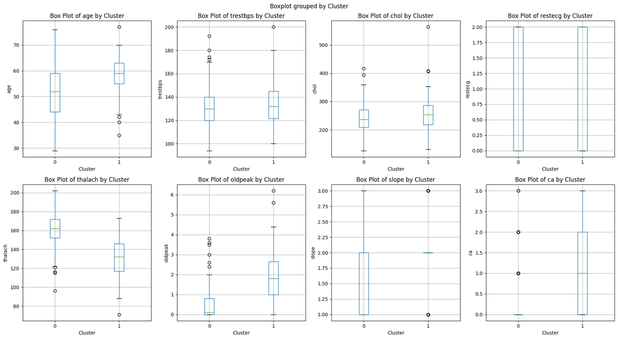

```python
# Box plots of the numerical variables

# List of features to include in the box plot
features_to_plot = ['age', 'trestbps', 'chol', 'restecg', 'thalach', 'oldpeak', 'slope', 'ca']

# Create subplots with 4 plots per row
num_plots = len(features_to_plot)
num_rows = (num_plots + 2) // 4  # Calculate the number of rows needed
fig, axes = plt.subplots(num_rows, 4, figsize=(18, 5 * num_rows))

# Flatten the axes array for easier iteration
axes = axes.flatten()

for i, feature in enumerate(features_to_plot):
  if i < num_plots:
    df.boxplot(column=feature, by='Cluster', ax=axes[i])
    axes[i].set_title(f'Box Plot of {feature} by Cluster')
    axes[i].set_xlabel('Cluster')
    axes[i].set_ylabel(feature)

# Turn off any unused subplots
for i in range(num_plots, len(axes)):
    fig.delaxes(axes[i])


plt.tight_layout()
plt.show()
```

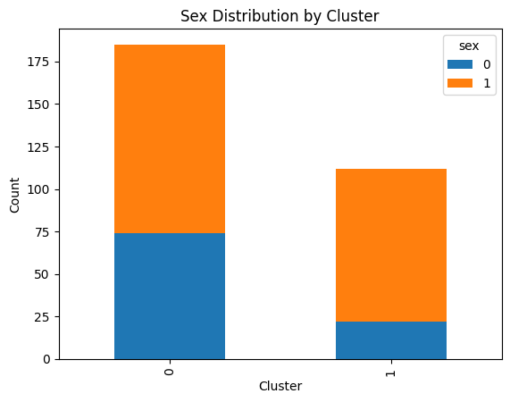

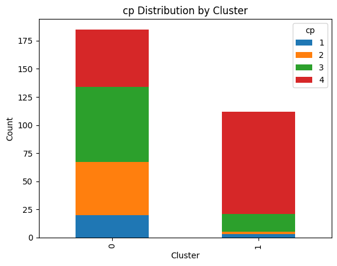

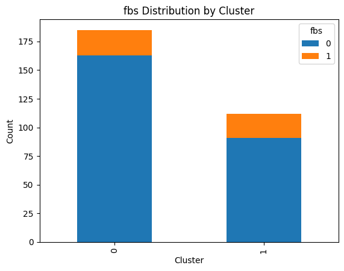

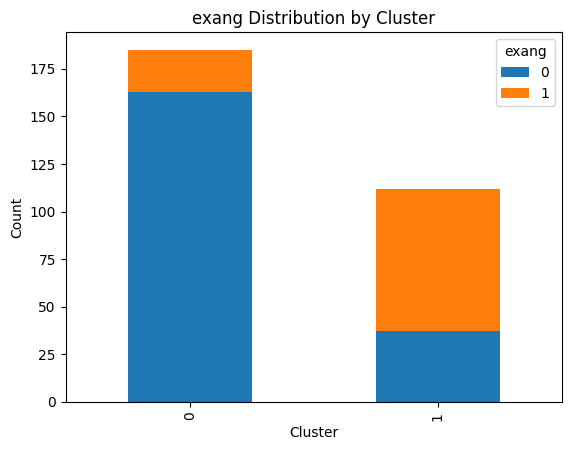

```python
# Plot of categorical variables

# Create the piled bar graph for 'sex'
plt.figure(figsize=(8, 6))
df.groupby(['Cluster', 'sex']).size().unstack().plot(kind='bar', stacked=True)
plt.title('Sex Distribution by Cluster')
plt.xlabel('Cluster')
plt.ylabel('Count')
plt.show()

# Create the piled bar graph for 'cp'
plt.figure(figsize=(8, 6))
df.groupby(['Cluster', 'cp']).size().unstack().plot(kind='bar', stacked=True)
plt.title('cp Distribution by Cluster')
plt.xlabel('Cluster')
plt.ylabel('Count')
plt.show()

# Create the piled bar graph for 'fbs'
plt.figure(figsize=(8, 6))
df.groupby(['Cluster', 'fbs']).size().unstack().plot(kind='bar', stacked=True)
plt.title('fbs Distribution by Cluster')
plt.xlabel('Cluster')
plt.ylabel('Count')
plt.show()

# Create the piled bar graph for 'exang'
plt.figure(figsize=(8, 6))
df.groupby(['Cluster', 'exang']).size().unstack().plot(kind='bar', stacked=True)
plt.title('exang Distribution by Cluster')
plt.xlabel('Cluster')
plt.ylabel('Count')
plt.show()
```

## 3. Forecasting patient no-shows for medical appointments

1. Which machine learning methods did you implement? The machine learning methods implemented were LightGBM and XGBoost. LightGBM, initially, achieved high sensitivity but low specificity, effectively identifying patients who would attend but not those who would miss appointments. Downsampling significantly improved specificity in LightGBM by addressing class imbalance, making it more suitable for predicting no-shows.
2. Discuss the key contribution of each method to your analysis. XGBoost showed similar performance to LightGBM, both benefiting from downsampling. However, LightGBM was preferred due to its computational efficiency without compromising performance.
3. Did all methods support your conclusions or did some provide conflicting results? If so they provided conflicting results, how did you reconcile the differences? Both methods supported the conclusion that downsampling improved the model's ability to predict no-shows. The difference in computational efficiency led to choosing LightGBM over XGBoost, as the performance difference was negligible.

### Forecasting Patient No-shows Code

```python
# import packages
import pandas as pd
from sklearn.model_selection import train_test_split
from sklearn.preprocessing import StandardScaler
from sklearn.svm import SVC
from sklearn.model_selection import KFold
from sklearn.metrics import accuracy_score, classification_report, roc_curve, auc
```

```python
# Fetching the Data
# get data from /content/healthcare_noshows_appt.csv

df = pd.read_csv('/content/healthcare_noshows_appt.csv')
print(df.head())
```

```
      PatientId  AppointmentID Gender ScheduledDay AppointmentDay   Age  \
0  2.987250e+13      5642903.0      F   2016-04-29     2016-04-29  62.0
1  5.589978e+14      5642503.0      M   2016-04-29     2016-04-29  56.0
2  4.262962e+12      5642549.0      F   2016-04-29     2016-04-29  62.0
3  8.679512e+11      5642828.0      F   2016-04-29     2016-04-29   8.0
4  8.841186e+12      5642494.0      F   2016-04-29     2016-04-29  56.0

       Neighbourhood Scholarship Hipertension Diabetes Alcoholism Handcap  \
0    JARDIM DA PENHA       False         True    False      False   False
1    JARDIM DA PENHA       False        False    False      False   False
2      MATA DA PRAIA       False        False    False      False   False
3  PONTAL DE CAMBURI       False        False    False      False   False
4    JARDIM DA PENHA       False         True     True      False   False

  SMS_received Showed_up  Date.diff
0        False      True        0.0
1        False      True        0.0
2        False      True        0.0
3        False      True        0.0
4        False      True        0.0
```

```python
df.info()
df.head()
```

```
<class 'pandas.core.frame.DataFrame'>
RangeIndex: 48223 entries, 0 to 48222
Data columns (total 15 columns):
 #   Column          Non-Null Count  Dtype
---  ------          --------------  -----
 0   PatientId       48223 non-null  float64
 1   AppointmentID   48222 non-null  float64
 2   Gender          48222 non-null  object
 3   ScheduledDay    48222 non-null  object
 4   AppointmentDay  48222 non-null  object
 5   Age             48222 non-null  float64
 6   Neighbourhood   48222 non-null  object
 7   Scholarship     48222 non-null  object
 8   Hipertension    48222 non-null  object
 9   Diabetes        48222 non-null  object
 10  Alcoholism      48222 non-null  object
 11  Handcap         48222 non-null  object
 12  SMS_received    48222 non-null  object
 13  Showed_up       48222 non-null  object
 14  Date.diff       48222 non-null  float64
dtypes: float64(4), object(11)
memory usage: 5.5+ MB
```

|  | PatientId | AppointmentID | Gender | ScheduledDay | AppointmentDay | Age | Neighbourhood | Scholarship | Hipertension | Diabetes | Alcoholism | Handcap | SMS_received | Showed_up | Date.diff |
| --- | --- | --- | --- | --- | --- | --- | --- | --- | --- | --- | --- | --- | --- | --- | --- |
| 0 | 2.987250e+13 | 5642903.0 | F | 2016-04-29 | 2016-04-29 | 62.0 | JARDIM DA PENHA | False | True | False | False | False | False | True | 0.0 |
| 1 | 5.589978e+14 | 5642503.0 | M | 2016-04-29 | 2016-04-29 | 56.0 | JARDIM DA PENHA | False | False | False | False | False | False | True | 0.0 |
| 2 | 4.262962e+12 | 5642549.0 | F | 2016-04-29 | 2016-04-29 | 62.0 | MATA DA PRAIA | False | False | False | False | False | False | True | 0.0 |
| 3 | 8.679512e+11 | 5642828.0 | F | 2016-04-29 | 2016-04-29 | 8.0 | PONTAL DE CAMBURI | False | False | False | False | False | False | True | 0.0 |
| 4 | 8.841186e+12 | 5642494.0 | F | 2016-04-29 | 2016-04-29 | 56.0 | JARDIM DA PENHA | False | True | True | False | False | False | True | 0.0 |

```python
import lightgbm as lgb
from sklearn.model_selection import train_test_split, GridSearchCV
from sklearn.metrics import accuracy_score, precision_score, recall_score, f1_score, roc_auc_score, confusion_matrix
import matplotlib.pyplot as plt
import seaborn as sns
from sklearn.preprocessing import LabelEncoder # Import LabelEncoder for encoding
```

```python
# Step 1: Load the Data
df = pd.read_csv('/content/healthcare_noshows_appt.csv')

# To use the resource better we will extract randomly 2000 rows of the df
df = df.sample(n=2000, random_state=42)  # random_state for reproducibility
print(df.info())
```

```
<class 'pandas.core.frame.DataFrame'>
Index: 2000 entries, 87067 to 55927
Data columns (total 15 columns):
 #   Column          Non-Null Count  Dtype
---  ------          --------------  -----
 0   PatientId       2000 non-null   float64
 1   AppointmentID   2000 non-null   int64
 2   Gender          2000 non-null   object
 3   ScheduledDay    2000 non-null   object
 4   AppointmentDay  2000 non-null   object
 5   Age             2000 non-null   int64
 6   Neighbourhood   2000 non-null   object
 7   Scholarship     2000 non-null   bool
 8   Hipertension    2000 non-null   bool
 9   Diabetes        2000 non-null   bool
 10  Alcoholism      2000 non-null   bool
 11  Handcap         2000 non-null   bool
 12  SMS_received    2000 non-null   bool
 13  Showed_up       2000 non-null   bool
 14  Date.diff       2000 non-null   int64
dtypes: bool(7), float64(1), int64(3), object(4)
memory usage: 154.3+ KB
None
```

```python
# Show table grouping df by "Showed_up" value ad a percentage of each option
df_showed_up_percentage = df.groupby('Showed_up')['Showed_up'].count() / len(df) * 100
df_showed_up_percentage
```

| Showed_up | Showed_up |
| --- | --- |
| False | 20.6 |
| True | 79.4 |

**dtype:** float64

```python
# save df as csv
df.to_csv('df_saved.csv', index=False)
```

The data is highly imbalanced, affecting the specificity which is what we want to predict. To fix this we will downsample in the next interation.

#### Light Gradient-Boosting Machine (LightGBM)

```python
# Step 2: Data Preprocessing
# Convert date columns to datetime
df['ScheduledDay'] = pd.to_datetime(df['ScheduledDay'])
df['AppointmentDay'] = pd.to_datetime(df['AppointmentDay'])

# Create date-based features
df['ScheduledDay_of_week'] = df['ScheduledDay'].dt.dayofweek
df['AppointmentDay_of_week'] = df['AppointmentDay'].dt.dayofweek
df['Date.diff'] = (df['AppointmentDay'] - df['ScheduledDay']).dt.days

# Drop irrelevant columns
df.drop(['PatientId', 'AppointmentID', 'ScheduledDay', 'AppointmentDay'], axis=1, inplace=True)

# Encode categorical variables:
# LightGBM can handle categorical data directly, but we'll use encoding here for simplicity
df['Gender'] = df['Gender'].map({'M': 0, 'F': 1})
df['Showed_up'] = df['Showed_up'].astype(int)

# Encode 'Neighbourhood' using Label Encoding
le = LabelEncoder() # Create a LabelEncoder object
df['Neighbourhood'] = le.fit_transform(df['Neighbourhood']) # Fit and transform the 'Neighbourhood' column

# Define features and target variable
X = df.drop('Showed_up', axis=1)
y = df['Showed_up']

# Split Data
X_train, X_test, y_train, y_test = train_test_split(X, y, test_size=0.2, random_state=42)

# Initialize LightGBM Model
lgbm = lgb.LGBMClassifier(objective='binary', boosting_type='gbdt', random_state=42)

# Train the Model
lgbm.fit(X_train, y_train)
```

[output not shown]

```
LGBMClassifier(objective='binary', random_state=42)
```

```
Initial Model Performance:
Accuracy: 0.78
Precision: 0.84
Recall: 0.89
F1 Score: 0.87
ROC-AUC Score: 0.57
```

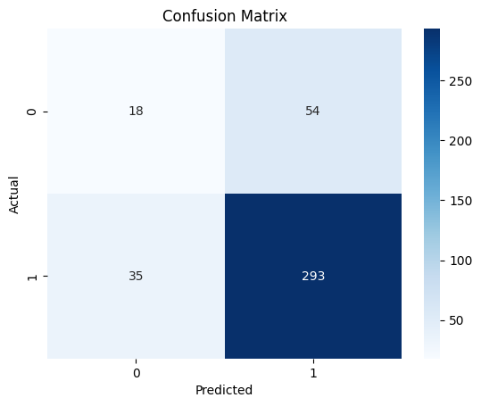

```
Fitting 5 folds for each of 81 candidates, totalling 405 fits
```

```
[LightGBM] [Info] Number of positive: 1260, number of negative: 340
[LightGBM] [Info] Auto-choosing row-wise multi-threading, the overhead of testing was 0.000295 seconds.
You can set `force_row_wise=true` to remove the overhead.
And if memory is not enough, you can set `force_col_wise=true`.
[LightGBM] [Info] Total Bins 245
[LightGBM] [Info] Number of data points in the train set: 1600, number of used features: 12
[LightGBM] [Info] [binary:BoostFromScore]: pavg=0.787500 -> initscore=1.309921
[LightGBM] [Info] Start training from score 1.309921
Best parameters found by GridSearch: {'learning_rate': 0.01, 'max_depth': 10, 'n_estimators': 200, 'num_leaves': 31}

Final Model Performance with Tuned Parameters:
Accuracy: 0.81
Specificity: 0.11
Precision: 0.83
Recall: 0.97
F1 Score: 0.89
ROC-AUC Score: 0.54
```

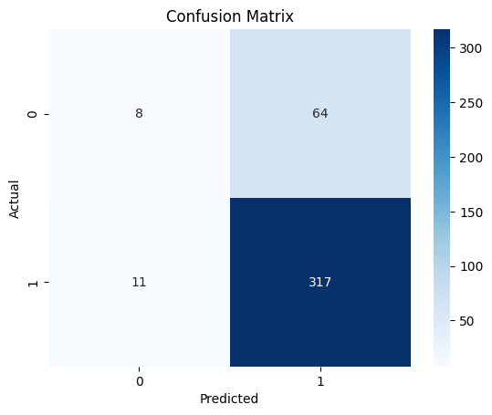

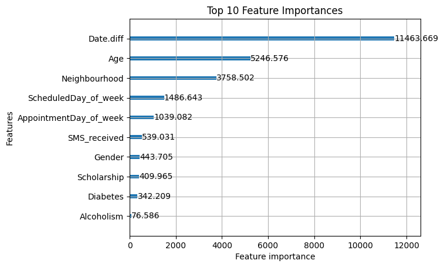

```python
# Predict and Evaluate Initial Performance
y_pred = lgbm.predict(X_test)

# Calculate metrics
accuracy = accuracy_score(y_test, y_pred)
precision = precision_score(y_test, y_pred)
recall = recall_score(y_test, y_pred)
f1 = f1_score(y_test, y_pred)
roc_auc = roc_auc_score(y_test, y_pred)

# Print initial metrics
print("Initial Model Performance:")
print(f"Accuracy: {accuracy:.2f}")
print(f"Precision: {precision:.2f}")
print(f"Recall: {recall:.2f}")
print(f"F1 Score: {f1:.2f}")
print(f"ROC-AUC Score: {roc_auc:.2f}")

# Confusion Matrix
sns.heatmap(confusion_matrix(y_test, y_pred), annot=True, fmt='d', cmap='Blues')
plt.xlabel("Predicted")
plt.ylabel("Actual")
plt.title("Confusion Matrix")
plt.show()

# Hyperparameter Tuning
param_grid = {
    'num_leaves': [31, 50, 70],
    'learning_rate': [0.1, 0.01, 0.001],
    'n_estimators': [100, 200, 500],
    'max_depth': [-1, 10, 20]
}

# Using GridSearchCV for hyperparameter tuning
grid_search = GridSearchCV(estimator=lgbm, param_grid=param_grid, cv=5, scoring='roc_auc', n_jobs=-1, verbose=1)
grid_search.fit(X_train, y_train)

# Get the best model
best_lgbm = grid_search.best_estimator_
print("Best parameters found by GridSearch:", grid_search.best_params_)

# Final Model Evaluation
y_pred_final = best_lgbm.predict(X_test)

# Specificity
tn, fp, fn, tp = confusion_matrix(y_test, y_pred_final).ravel()

# Final metrics
final_accuracy = accuracy_score(y_test, y_pred_final)
final_precision = precision_score(y_test, y_pred_final)
final_recall = recall_score(y_test, y_pred_final)
final_f1 = f1_score(y_test, y_pred_final)
final_roc_auc = roc_auc_score(y_test, y_pred_final)
final_specificity = tn / (tn + fp)

print("\nFinal Model Performance with Tuned Parameters:")
print(f"Accuracy: {final_accuracy:.2f}")
print(f"Specificity: {final_specificity:.2f}")
print(f"Precision: {final_precision:.2f}")
print(f"Recall: {final_recall:.2f}")
print(f"F1 Score: {final_f1:.2f}")
print(f"ROC-AUC Score: {final_roc_auc:.2f}")

# Confusion Matrix
sns.heatmap(confusion_matrix(y_test, y_pred_final), annot=True, fmt='d', cmap='Blues')
plt.xlabel("Predicted")
plt.ylabel("Actual")
plt.title("Confusion Matrix")
plt.show()
print("\n")

# Feature Importance
lgb.plot_importance(best_lgbm, max_num_features=10, importance_type="gain")
plt.title("Top 10 Feature Importances")
plt.show()
```

Comparing LightGBM and XGBoost Models with downsampling